# Back-calculated WA Test

Tor Kitching

2024-01-03

## Check for Back-Calculated Watershed Areas

The purpose of this document is to test the back-calculated watershed areas. All code will be drawn from the IWAM function vignette.

## S1. Data Map

The following function vignette/example is from the IWAM Package Repo hosted publicly through the Pacific Salmon Assess organization available at [this link.](https://github.com/Pacific-salmon-assess/iwam-package)

The package currently utilizes the following data sets:

- *SRinputfile (Private)*: Private data-sets developed by Parken et al. (2006). Required to run the complete function and is available upon request. To be updated with publicly available data. Life histories are included: 1 = ocean type, 0 = stream type. Contains stock names, year, spawners, recruits, and life history identification.
- *WatershedArea (Public)*: Internal input containing watershed areas per stock.
- *CUPars_nBC (Public)*: Input file with Ricker $\alpha$’s without bias correction (CITATION) from Diana Dobson’s Run Reconstruction coded in TMB. Has a higher estimate of Ricker $\alpha$ (lower Sgen).
- *CUPars_wBC (Public)*: Input file with Ricker $\alpha$’s with bias correction (CITATION) from Diana Dobson’s Run Reconstruction coded in TMB. Has a higher estimate of Ricker $\alpha$ (lower Sgen).
- *Backcalc_targetstocks (Public)*: Back-calculated user watershed area input file. Watershed areas calculated based on Parken estimates of SMSY and SREP. All aggregate information; CU, and Inlet, have been removed. PLEASE NOTE: All WCVI stocks use watershed areas with input from WCVI Staff: Nahmint, Sarita, Somass, Bedwell/Ursus, Cypre, Megin, Moyeha, Tranquil, Artlish, Kaouk, Tahsish, Nitinat, Burman, Conuma, Gold, Leiner, Tahsis, Zeballos, Cayeghle, Marble, San Juan, Canton Creek, Espinosa, Kauwinch River, Kleeptee, Little Zeballos River, Malksope River, McKay Cove Creek, Mooyah River, Ououkinsh River, Sucwoa River, Tlupana River, Tsowwin River. PLEASE NOTE: duplicate stock/river names are no acceptable for example in the case of Seymour river - please specify their difference - Georgia Strait vs. South Thompson origins in the river name itself. Duplicate river names will result in a invalid object lengths error when running the IWAM function.

## S2. Initialize function

```r
IWAM_backcalc <- IWAM_func(WAin = "DataIn/Ordered_backcalculated_noagg.csv", # Data (INPUT)
                       # Ordered_backcalculated_noagg - ordered corrected to original input file
                       # Backcalc_targetstocks_NoAgg.csv - broken due to alphabetical ordering
                       remove.EnhStocks = FALSE, # Remove Enhancement stocks (INPUT)
                       run.bootstrap = TRUE, # TRUE/FALSE for running the bootstrap process
                       bs_seed = 1, # Change the internal seed for the bootstrap (INPUT)
                       bs_nBS = 10, # Change the internal number of trials for the bootstrap (INPUT)
                       # Run 10 for testing purposes - otherwise 20000
                       plot = FALSE, # Print plots to DataOut/
                       est.table = FALSE # Store tables
)
```

## S3. Check outputs

This code is a direct lift from the IWAM function vignette. Once the model and bootstrapping has completed, the function will store the following objects:

- `dfout`: A complete data frame containing the SGEN, SREP, and SMSY estimates for each stock and their upper and lower quantiles.

The following tables (1-3) have been prepared for comparison to Holt et al. (2023) Res Doc (Table 9).

*Table 1. SGEN, SREP, and SMSY estimates including 0.25% and 97.5% quantiles for all listed stocks. Watershed areas are back-calculated from Parken estimates with the exception of all WCVI stocks, which use original watershed areas: Nahmint, Sarita, Somass, Bedwell/Ursus, Cypre, Megin, Moyeha, Tranquil, Artlish, Kaouk, Tahsish, Nitinat, Burman, Conuma, Gold, Leiner, Tahsis, Zeballos, Cayeghle, Marble, San Juan, Canton Creek, Espinosa, Kauwinch River, Kleeptee, Little Zeballos River, Malksope River, McKay Cove Creek, Mooyah River, Ououkinsh River, Sucwoa River, Tlupana River, Tsowwin River.*

SGEN, SREP, and SMSY Estimates for All Stocks

| Stock | WA | SGEN | SGEN LQ | SGEN UQ | SREP | SREP LQ | SREP UQ | SMSY | SMSY LQ | SMSY UQ |
| --- | --- | --- | --- | --- | --- | --- | --- | --- | --- | --- |
| South Thompson Agg | 29565 | 84000.0 | 18000.00 | 230000 | 490000 | 270000 | 700000 | 210000.0 | 110000.0 | 310000 |
| Lower Shuswap | 2663 | 9300.0 | 1900.00 | 33000 | 45000 | 29000 | 70000 | 18000.0 | 12000.0 | 34000 |
| Middle Shuswap | 640 | 2300.0 | 1100.00 | 6300 | 12000 | 8900 | 18000 | 5000.0 | 3700.0 | 7400 |
| Wap | 20 | 61.0 | 19.00 | 200 | 330 | 140 | 610 | 140.0 | 58.0 | 280 |
| East | 46 | 120.0 | 55.00 | 300 | 680 | 380 | 1400 | 290.0 | 160.0 | 630 |
| Goodspeed | 15 | 49.0 | 19.00 | 120 | 300 | 130 | 420 | 130.0 | 54.0 | 180 |
| Keith | 56 | 200.0 | 130.00 | 520 | 1000 | 630 | 1400 | 450.0 | 280.0 | 590 |
| Klaskish | 41 | 110.0 | 45.00 | 280 | 650 | 320 | 1200 | 280.0 | 130.0 | 520 |
| Mahatta | 114 | 210.0 | 94.00 | 710 | 1500 | 870 | 3000 | 590.0 | 350.0 | 1200 |
| Washlawlis | 23 | 75.0 | 31.00 | 210 | 440 | 270 | 840 | 170.0 | 110.0 | 380 |
| Colonial&Cayeagle | 79 | 420.0 | 130.00 | 690 | 1700 | 1000 | 2400 | 720.0 | 460.0 | 1100 |
| Marble | 168 | 370.0 | 73.00 | 1700 | 3100 | 1500 | 6500 | 1200.0 | 520.0 | 2900 |
| Adam | 279 | 860.0 | 520.00 | 1200 | 4800 | 2100 | 6500 | 2000.0 | 940.0 | 2800 |
| Amor de Cosmos | 15 | 43.0 | 20.00 | 130 | 210 | 92 | 270 | 91.0 | 42.0 | 130 |
| Cluxewe | 90 | 320.0 | 92.00 | 1100 | 1600 | 1100 | 2200 | 730.0 | 420.0 | 1100 |
| Kokish | 104 | 460.0 | 94.00 | 1100 | 1500 | 690 | 2600 | 700.0 | 330.0 | 1300 |
| Quatse | 80 | 290.0 | 160.00 | 690 | 1500 | 970 | 1900 | 610.0 | 430.0 | 880 |
| Nimpkish (above Lake) | 400 | 1600.0 | 570.00 | 2700 | 6700 | 4400 | 11000 | 2900.0 | 1900.0 | 5100 |
| Salmon | 912 | 2800.0 | 990.00 | 9700 | 15000 | 7300 | 28000 | 6100.0 | 3100.0 | 13000 |
| Quinsam-Campbell | 171 | 350.0 | 190.00 | 1000 | 2700 | 1500 | 3400 | 1100.0 | 640.0 | 1600 |
| Conuma | 20 | 59.0 | 17.00 | 160 | 290 | 160 | 510 | 120.0 | 67.0 | 230 |
| Tahsis | 77 | 230.0 | 77.00 | 600 | 1100 | 770 | 2600 | 470.0 | 320.0 | 1200 |
| Burman | 70 | 240.0 | 72.00 | 520 | 1100 | 780 | 2400 | 490.0 | 300.0 | 1000 |
| Artlish | 64 | 290.0 | 110.00 | 560 | 890 | 480 | 1800 | 410.0 | 220.0 | 750 |
| Kaouk | 101 | 290.0 | 66.00 | 750 | 1400 | 1000 | 2700 | 630.0 | 400.0 | 1200 |
| Tahsish | 172 | 310.0 | 110.00 | 1000 | 2100 | 1300 | 3600 | 870.0 | 530.0 | 1400 |
| Gold | 856 | 2700.0 | 760.00 | 7100 | 15000 | 9600 | 22000 | 6900.0 | 3700.0 | 9900 |
| Leiner | 109 | 220.0 | 120.00 | 1300 | 1900 | 870 | 3300 | 840.0 | 390.0 | 1500 |
| Zeballos | 194 | 570.0 | 440.00 | 1700 | 2600 | 2000 | 4300 | 1100.0 | 900.0 | 2000 |
| Amai | 14 | 28.0 | 16.00 | 210 | 170 | 100 | 950 | 72.0 | 44.0 | 420 |

[output cut: 85 more lines]

## S4. Comparative Plotting

The objective of this section is to provide comparison figures between the IWAM function’s estimates of SMSY and SREP to the Parken model estimates.

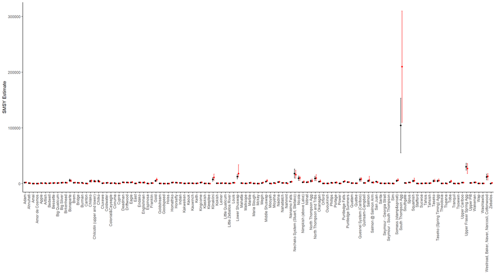

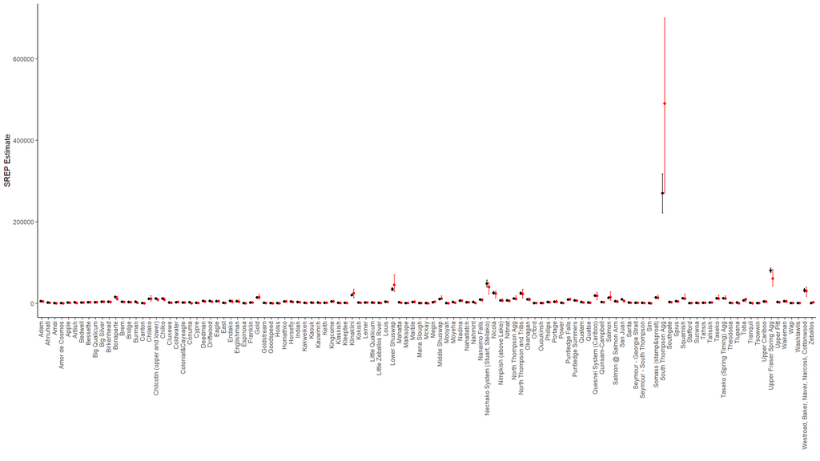